# Fitting logistic growth - PROC model

## Model

The logistic growth model can be written in the $r,\alpha$ or the $r,K$ formulation, where $K=\frac{r}{\alpha}$, or $\alpha=\frac{r}{K}$:

$$\begin{aligned}
\frac{dN}{dt} &= (r-\alpha N)N \\ &=r(1-\frac{N}{K})N
\end{aligned}$$
Using one-step-ahead fitting (process error only), we will fit all datapoints $N_t$ of $m$ timeseries replicates with predictions based on their previous observations $N_{t-1}$. A joint set of model parameters $r$ and $K$ is used.

## Data preparation

The dataset `data_example_logistic.csv` contains `m=6` timeseries with `n=18` observations of densities [ind] each, including their dates [h]. The fraction of the observed volume for sampling was `f=0.1`. Data preparation is identical to the OBS model manual.

```r
rm(list=ls())
library("rstan")
data.in = read.csv("data_example_logistic.csv", row.names=1)

head(data.in)
```

```
##      X1 X2  X3  X4  X5  X6  X7   X8   X9  X10  X11  X12  X13  X14  X15  X16
## time  0 12  24  36  48  60  72   96  120  144  168  192  216  240  264  288
## N1   10 36 106 270 562 914 994  968  904 1032 1010 1004  968 1010 1048  950
## N2   24 30 136 262 532 846 942 1024 1024 1010 1016 1002 1082 1056  958 1088
## N3   10 20 146 336 660 896 938  946 1016 1044  966  994 1004 1008 1086  932
## N4   12 44 120 274 572 768 916 1010 1058 1066  992 1006  940  910 1016  998
## N5   10 20  62 142 484 656 922  934 1000 1052  988 1004 1036 1056 1020  932
##       X17  X18
## time  312  336
## N1    952 1072
## N2   1078  954
## N3   1006 1034
## N4    916  972
## N5   1062  976
```

```r
n = ncol(data.in)
m = nrow(data.in)-1

times = as.numeric(data.in[1, ])
N = unname(as.matrix(data.in[2:(m+1), ]))

data = list(n = n,
            m = m,
            t = times,
            N = N,
            f = 0.1)

str(data)
```

```
## List of 5
##  $ n: int 18
##  $ m: num 6
##  $ t: num [1:18] 0 12 24 36 48 60 72 96 120 144 ...
##  $ N: int [1:6, 1:18] 10 24 10 12 10 10 36 30 20 44 ...
##  $ f: num 0.1
```

## Stan model

The Stan model is coded as a string, which is compiled later. A step by step walkthrough is given below.

```r
stanmodelcode = '
functions{
  real[] odemodel(real t, real[] N, real[] p, real[] x_r, int[] x_i){
    // p[1]=r, p[2]=K
    real dNdt[1];
    dNdt[1] = p[1]*(1-(N[1]/p[2]))*N[1];
    return dNdt;
  }
}

data{
  int n; // observations
  int m; // replicates
  real t[n];
  int N[m,n];
  real f;
}

parameters{
  real<lower=0> r;
  real<lower=0> K;
  real<lower=0> tau;
}

model{
  real p[2];
  real Nsim[1,1]; // simulated values, matrix. dim1 = 1 point in time, dim2 = dim_ODE = 1

  // priors (uninformative)
  r ~ lognormal(-2,1);
  K ~ lognormal(9,1);
  tau ~ gamma(2,0.1);

  // parameters for integrator
  p[1] = r;
  p[2] = K;

  for(j in 1:m){
    for(i in 1:(n-1)){
      if(N[j,i]>0){
        // integrate ODE
        Nsim = integrate_ode_rk45(odemodel, {N[j,i]/f}, t[i], {t[i+1]}, p, rep_array(0.0,0), rep_array(0,0));
        // likelihood
        N[j,i+1] ~ neg_binomial_2(Nsim[1,1]*f,tau);
      }
    }
  }
}
'
```

### functions{ } block

This is identical to the OBS model manual.

```
  real[] odemodel(real t, real[] N, real[] p, real[] x_r, int[] x_i){
    // p[1]=r, p[2]=K
    real dNdt[1];
    dNdt[1] = p[1]*(1-(N[1]/p[2]))*N[1];
    return dNdt;
  }
```

### data{ } block

This is identical to the OBS model manual.

```
  int n; // observations
  int m; // replicates
  real t[n];
  int N[m,n];
```

### parameters{ } block

Here, all free parameters are declared. This includes model parameters `r` and `K`, and a parameter `tau` for the residual distribution (overdispersion of the negative binomial). All parameters are required to be positive.

```
  real<lower=0> r;
  real<lower=0> K;
  real<lower=0> tau;
```

### model{ } block

This block defines how the posterior computed, using prior distributions and the likelihood function. First, some intermediate variables for the ODE simulation are declared. `p` is an array which stores model parameters `r` and `K`. `Nsim` will contain the output of the numerical integration with dimensions `1` (predict only next state), and the second dimension is number of states (here just 1).

```
  real p[2];
  real Nsim[1,1]; // simulated values, matrix. dim1 = 1 point in time, dim2 = dim_ODE = 1
```

Priors: This is identical to the OBS model manual.

```
  r ~ lognormal(-2,1);
  K ~ lognormal(9,1);
  tau ~ gamma(2,0.1);
```

After the priors are defined, predictions are computed. This includes numerically integrating the ODE, which requires all model parameters are stored in one array `p`.

```
  p[1] = r;
  p[2] = K;
```

In a loop over all `m` time series replicates and `n-1` timepoints, numerical integration is performed, to predict the next state `N[j,i+1]` from the current state `N[j,i]`. Observed data is abundance in sampling fraction `f`, so the initial values are scaled up to the total volume (`N[j,i]/f`) for numerical integration, and predictions are scaled down later to the sampling fraction (`Nsim[1,1]*f`) for calculating residuals. The integration routine `integrate_ode_rk45()` is must be called in a specific format. Arguments are the function `odemodel` as defined in the `functions{}` block. The initial state is converted to an array using `{ }`. Integration is performed from `t[i]` to `t[i+1]`. `p` contains the model parameters. For additional variables `x_r` and `x_i` (mandatory but not used here), empty arrays are generated.

After computing the predicted state `Nsim` (in `t[i+1]`), it is confronted with the data `N[j,i+1]`: a negative binomial distribution defines likelihood values. Since the data was sampled in a fraction `f=0.1`, the distribution’s mean is `Nsim[,]*f`, with some overdispersion `tau`.

The prediction is only performed if `N[j,i]>0`. `N[j,i]=0` would predict a 0 in `t[i+1]` irrespective of the model parameters `r` and `K`, so it wouldn’t contribute any information to the likelihood function.

```
  for(j in 1:m){
    for(i in 1:(n-1)){
      if(N[j,i]>0){
        // integrate ODE
        Nsim = integrate_ode_rk45(odemodel, {N[j,i]/f}, t[i], {t[i+1]}, p, rep_array(0.0,0), rep_array(0,0));
        // likelihood
        N[j,i+1] ~ neg_binomial_2(Nsim[1,1]*f,tau);
      }
    }
  }
```

## Model fitting

This is identical to the OBS model manual.

```r
# stan options
chains = 3
rstan_options(auto_write = TRUE)
options(mc.cores = chains)
iter   =  4000
warmup =  2000
```

Then starting values for all free parameters are provided as a list (in case of multiple chains: a list of lists) with initial guesses. Stan usually converges quickly towards the parameter region featuring a high probability density. But with ODEs involved, good initial guesses that do not cause numerical issues in ODE integration are often required.

```r
# initial values for sampling
init=rep(list(list(r=0.1,
                   K=1e4,
                   tau=10))
         ,chains)
```

Finally, the model is compiled and sampling is started.

```r
stanmodel = stan_model(model_code=stanmodelcode)

fit = sampling(stanmodel,
               data=data,
               iter=iter,
               warmup=warmup,
               chains=chains,
               init=init
)
```

## Model diagnostics

Convergence of the MCMC chains is checked, e.g. by looking at estimated model parameters. We check the effective sample size `n_eff` and the Gelman-Rubin diagnostics `Rhat` (should be <1.01), indicating that chains have mixed.

```r
print(fit, digits=3, pars=c("r","K"), probs=c(0.025, 0.5, 0.975))
```

```
## Inference for Stan model: b16cd10e0c1eaeb90e8e546724002b41.
## 3 chains, each with iter=4000; warmup=2000; thin=1;
## post-warmup draws per chain=2000, total post-warmup draws=6000.
##
##        mean se_mean      sd     2.5%      50%     97.5% n_eff  Rhat
## r     0.101   0.000   0.003    0.094     0.10     0.107  4940 1.001
## K 10021.477   2.206 154.556 9723.839 10019.26 10325.511  4909 1.000
##
## Samples were drawn using NUTS(diag_e) at Mon Apr  4 13:46:46 2022.
## For each parameter, n_eff is a crude measure of effective sample size,
## and Rhat is the potential scale reduction factor on split chains (at
## convergence, Rhat=1).
```

Additionally, chains are inspected visually via trace- and density plots.

```r
library("coda")
```

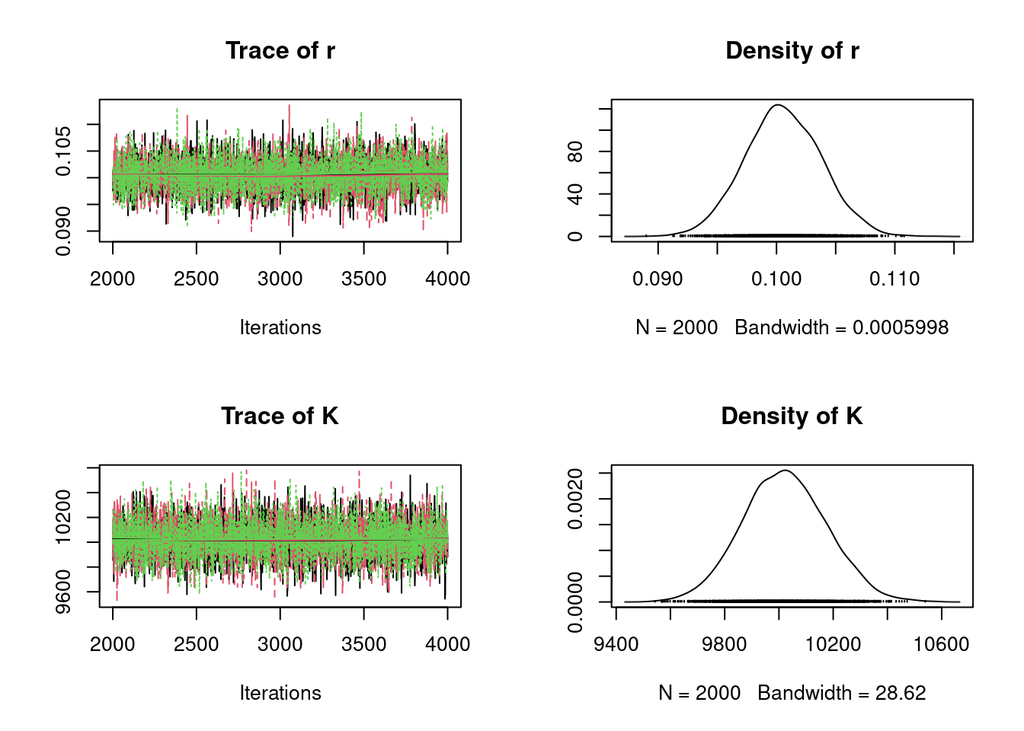

```r
samples=As.mcmc.list(fit)
plot(samples[, c("r","K")])
```

A pairs plot can detect correlations in model parameters. Almost perfect correlation would indicate non-identifiability.

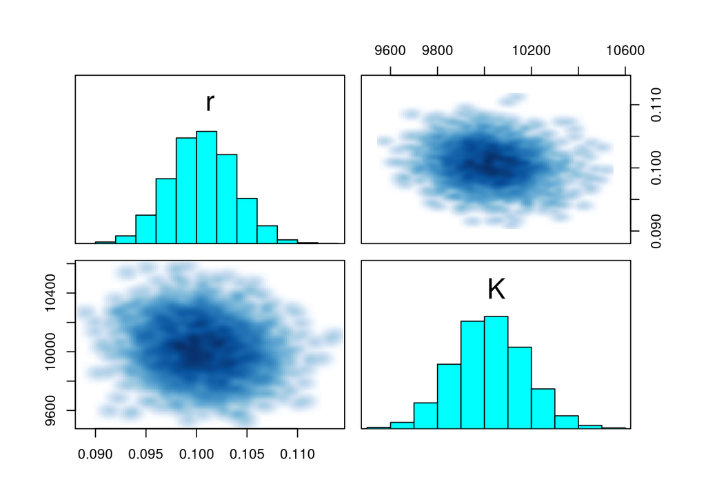

```r
pairs(fit, pars=c("r","K"))
```

## Posterior predictions

Posterior predictions are generated one-step-ahead from sampled posterior parameters. Alternatively, this can be done while sampling using `generated quantities{}` block in the model code. Here, we use the `deSolve` package for numerical integration to compute posterior predictions. First, we code an R function defining the population growth rate (ODE).

```r
library("deSolve")
ode.model = function(t,N,p){
  dNdt =  p[1]*N[1]*(1.0-N[1]/p[2])
  return(list(dNdt))
}
```

Samples of the posterior distribution are converted to matrix. Each column contains all samples of a single parameter, while each row contains one sample from the multivariate posterior distribution.

```r
post = as.matrix(fit)
# head(post)
```

The empty matrix `N.pred` will store all predicted values: each row will contain one sample of a predicted timeseries. Predictions are computed for each time series replicate (for-loop over `i`) and each timepoint (for-loop over `k`) separately. For each sample from the posterior (row `j` in matrix `post[j, ]`), each prediction is computed by numerically integrating the ODE with parameters `r` and `K`, starting in last observation `data$N[i,k]/data$f` (scaled up to total volume). Each column `k` of `N.pred[ ,k]` contains posterior predictions in `t[k+1]`. We calculate quantiles of these predictions and plot them against the data.

Since these are one-step-ahead predictions from the last observation, we plot them pointwise in time, rather than a trajectory as in the OBS model.

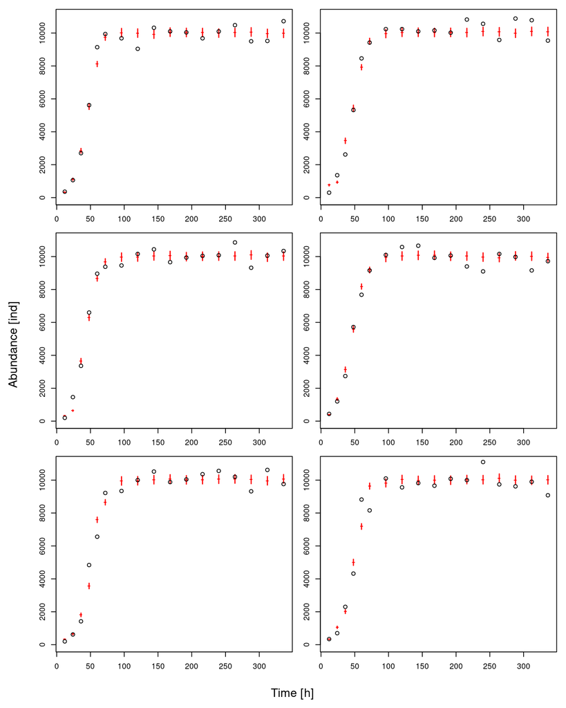

```r
post = as.matrix(fit)
n.post = nrow(post)
n.post = 1000

par(mfrow=c(3,2), mar=c(3,3,0,0), oma=c(3,3,1,1))
for(i in 1:m){

  N.pred = matrix(NA, nrow=n.post, ncol=length(data$t)-1)

  for(j in 1:n.post){
    for(k in 1:(length(data$t)-1)){
      N.pred[j,k] = as.data.frame(lsoda(y     = c( N = data$N[i,k]/data$f ),
                                        times = data$t[c(k,k+1)],
                                        func  = ode.model,
                                        parms = c(post[j, "r"],
                                                  post[j, "K"])
      ))$N[2]
    }
  }
  N.pred.qs = apply(N.pred, 2, function(x) quantile(x, probs=c(0.025,0.500,0.975), na.rm=TRUE))

  plot(data$t[2:n], data$N[i,2:n]/data$f,ylim=c(0,1.1e4), type="n", xlab="", ylab="")
  for(k in 1:(n-1)){
    lines(c(data$t[k+1],data$t[k+1]), c(N.pred.qs[1,k],N.pred.qs[3,k]), col="red", lwd=1.5)
  }
  points(data$t[2:n], N.pred.qs[2, ], col="red", pch="-", cex=1.5)
  points(data$t[2:n], data$N[i,2:n]/data$f, type="p")
}
mtext("Time [h]", side=1, outer=TRUE, line=1)
mtext("Abundance [ind]", side=2, outer=TRUE, line=1)
```